# coffee_sale

### 咖啡店銷售概況分析

這是我從kaggle上下載的有關於咖啡店銷售狀況的dataset

此dataset包含咖啡店交易記錄，包括銷售額、付款方式、購買時間和顧客偏好等資訊

本專案旨在整理與分析一筆包含交易紀錄的原始資料，並透過 ETL與 Tableau 視覺化，協助使用者快速掌握交易行為模式與營運重點

#### Extract

首先，用pandas讀取原始資料

```python
import pandas as pd
from IPython.display import display, HTML
# Extract
df = pd.read_csv("Coffe_sales.csv")
```

#### Transform

進行資料清理:

1.先把缺失值處理好

- 付款方式(cash_type)字首大寫
- 補上缺失的咖啡名稱(coffee_name)，標記為 Unknown
- 缺失的金額(money)補 0，避免計算錯誤

2.Time欄位因原始資料格式不統一，因此需特別處理

- 先把時間欄位轉成字串
- 如果沒有毫秒，就補 .000000
- 轉換格式，這樣 pandas 就知道怎麼 parse 了

```python
df["cash_type"] = df["cash_type"].str.capitalize()
df["coffee_name"] = df["coffee_name"].fillna("Unknown")
df["money"] = df["money"].fillna(0)
# 處理時間欄位
df["Time"] = df["Time"].astype(str).str.strip()
df["Time"] = df["Time"].apply(lambda x: x if "." in x else x + ".000000")
df["Time"] = pd.to_datetime(df["Time"], format="%H:%M:%S.%f", errors="coerce")
```

為了方便在Tableau上分析，多加一個欄位time_of_day，根據小時數分類為 Morning / Afternoon / Night

```python
# Time of Day 分類
def time_of_day(hour):
    if pd.isna(hour):
        return None
    elif 5 <= hour < 12:
        return "Morning"
    elif 12 <= hour < 17:
        return "Afternoon"
    else:
        return "Night"

df["Time_of_Day"] = df["hour_of_day"].apply(time_of_day)
```

```python
# Weekday & Weekdaysort
# 排序 (Mon=1 ~ Sun=7)，方便畫圖時按順序顯示
weekday_order = {"Mon": 1, "Tue": 2, "Wed": 3, "Thu": 4, "Fri": 5, "Sat": 6, "Sun": 7}
df["Weekdaysort"] = df["Weekday"].map(weekday_order)

# Month_name & Monthsort
## 月份排序 (Jan=1 ~ Dec=12)，避免字母排序錯亂
month_order = {"Jan":1, "Feb":2, "Mar":3, "Apr":4, "May":5, "Jun":6,
               "Jul":7, "Aug":8, "Sep":9, "Oct":10, "Nov":11, "Dec":12}
df["Monthsort"] = df["Month_name"].map(month_order)

# 是否週末
df["is_weekend"] = df["Weekday"].isin(["Sat", "Sun"])
```

新增欄位"Coffee_category"，方便在Tableau上分析咖啡熱門品項

```python
# 咖啡分類
def coffee_category(name):
    espresso_based = ["Latte", "Americano", "Cappuccino", "Espresso","Americano with Milk","Cortado"]
    if name in espresso_based:
        return "Espresso-based"
    elif "Hot Chocolate" in name or "Cocoa" in name:
        return "Non-coffee"
    else:
        return "Other"

df["Coffee_category"] = df["coffee_name"].apply(coffee_category)
html_table = df.head(10).to_html(index=False)
display(HTML('<div style="overflow-x:auto">' + html_table + '</div>'))
```

| hour_of_day | cash_type | money | coffee_name | Time_of_Day | Weekday | Month_name | Weekdaysort | Monthsort | Date | Time | is_weekend | Coffee_category |
| --- | --- | --- | --- | --- | --- | --- | --- | --- | --- | --- | --- | --- |
| 10 | Card | 38.7 | Latte | Morning | Fri | Mar | 5 | 3 | 2024-03-01 | 1900-01-01 10:15:50.520 | False | Espresso-based |
| 12 | Card | 38.7 | Hot Chocolate | Afternoon | Fri | Mar | 5 | 3 | 2024-03-01 | 1900-01-01 12:19:22.539 | False | Non-coffee |
| 12 | Card | 38.7 | Hot Chocolate | Afternoon | Fri | Mar | 5 | 3 | 2024-03-01 | 1900-01-01 12:20:18.089 | False | Non-coffee |
| 13 | Card | 28.9 | Americano | Afternoon | Fri | Mar | 5 | 3 | 2024-03-01 | 1900-01-01 13:46:33.006 | False | Espresso-based |
| 13 | Card | 38.7 | Latte | Afternoon | Fri | Mar | 5 | 3 | 2024-03-01 | 1900-01-01 13:48:14.626 | False | Espresso-based |
| 15 | Card | 33.8 | Americano with Milk | Afternoon | Fri | Mar | 5 | 3 | 2024-03-01 | 1900-01-01 15:39:47.726 | False | Espresso-based |
| 16 | Card | 38.7 | Hot Chocolate | Afternoon | Fri | Mar | 5 | 3 | 2024-03-01 | 1900-01-01 16:19:02.756 | False | Non-coffee |
| 18 | Card | 33.8 | Americano with Milk | Night | Fri | Mar | 5 | 3 | 2024-03-01 | 1900-01-01 18:39:03.580 | False | Espresso-based |
| 19 | Card | 38.7 | Cocoa | Night | Fri | Mar | 5 | 3 | 2024-03-01 | 1900-01-01 19:22:01.762 | False | Non-coffee |
| 19 | Card | 33.8 | Americano with Milk | Night | Fri | Mar | 5 | 3 | 2024-03-01 | 1900-01-01 19:23:15.887 | False | Espresso-based |

### Load

將清理完的交易資料存成新檔案

```python
df.to_excel('coffee_transactions_cleaned.xlsx', index=False)
print("ETL 完成，已存成 coffee_transactions_cleaned.xlsx")
```

### Tableau視覺化分析

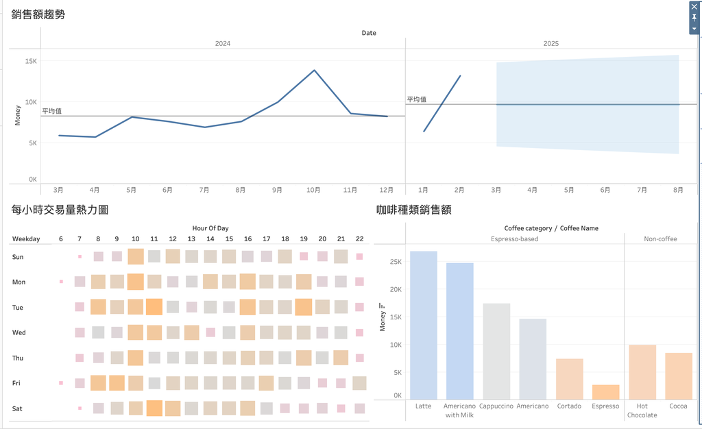

(1)銷售額趨勢

(2)每小時交易量熱力圖

(3)咖啡種類銷售額

- Latte 與 Americano 系列是銷售額最高的品項，顯示消費者可能偏好經典Espresso
- **Cappuccino 與 Americano**次之，仍屬於核心產品
- **非咖啡類**雖然銷售額不及咖啡，但仍有一定貢獻，可能吸引不喝咖啡的顧客。
- Espresso 本身銷售額最低，顯示純濃縮咖啡需求有限，市場主力還是在加奶或調味的咖啡飲品。